# EDA - Plotting System

Yaxin

Monday, August 25, 2014

### Base Plotting System in R

1. **Default**

```r
hist(airquality$Ozone)
with(airquality,plot(Wind,Ozone))
airquality <- transform(airquality, Month = factor(Month))
boxplot(Ozone~Month,airquality,xlab="Month",ylab="Ozone(ppb)")
```

Note:

Use `?par` to look up the parameters.

Use `par()` to specify global graphics parameters that affect all plots in an R session.

2. **Base Plotting Functions**
- `plot()`
- `lines()`: add lines to a plot;
- `points()`: add points to a plot;
- `text()`: add text labels to a plot;
- `title()`: add annotations to x,y axis labels;
- `mtext()`: add arbitrary text to the margins;
- `axis()`: add axis ticks/labels;
3. **Examples**

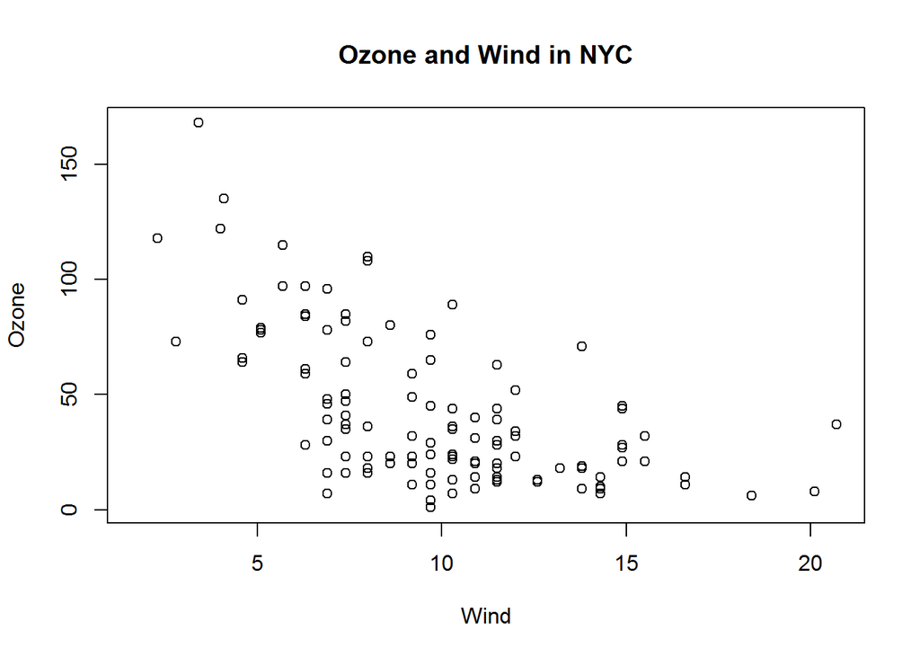

```r
library(datasets)
with(airquality, plot(Wind, Ozone))
title(main="Ozone and Wind in NYC") #add a title.
```

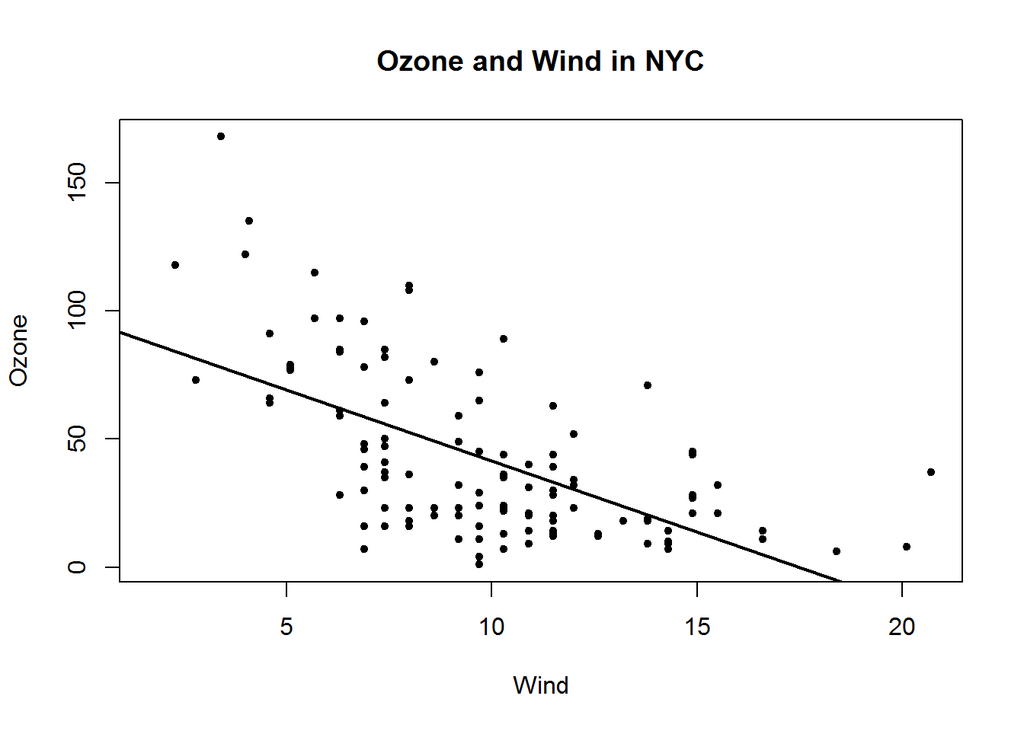

```r
#Base Plot with Regression Line
with(airquality,plot(Wind, Ozone,main="Ozone and Wind in NYC",pch=20))
model <- lm(Ozone~Wind,airquality)
abline(model,lwd=2)
```

4. **Multiple Base Plots**

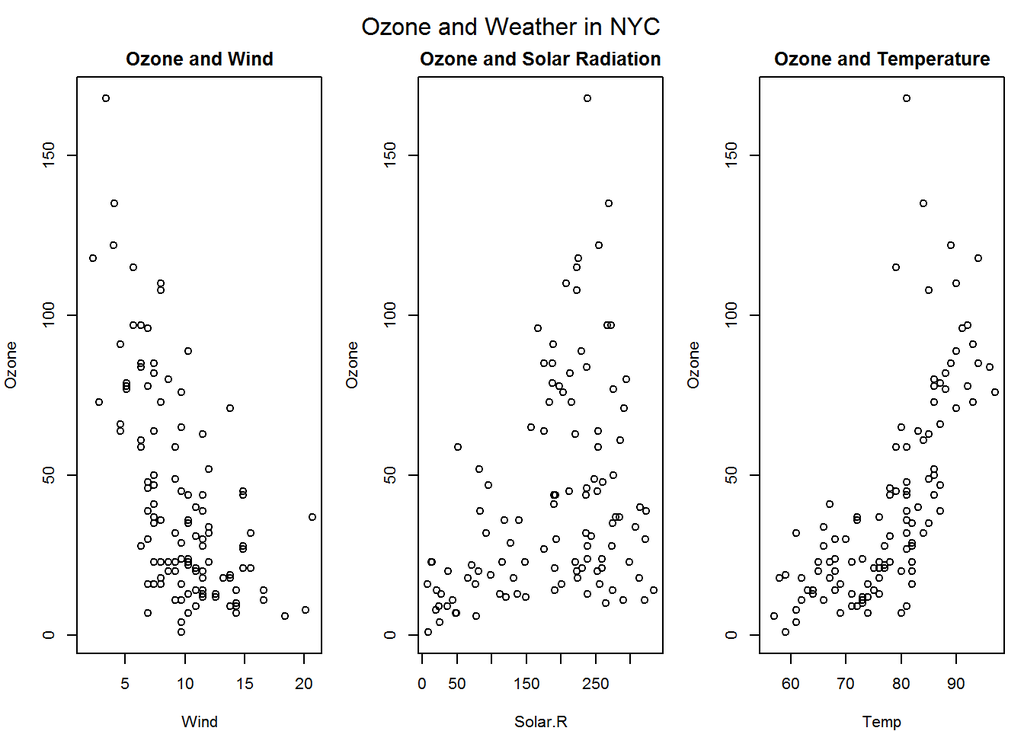

```r
# Please note the use of `mfrow`
par(mfrow=c(1,3),mar=c(4,4,2,1),oma=c(0,0,2,0))
with(airquality, {
    plot(Wind,Ozone,main="Ozone and Wind")
    plot(Solar.R, Ozone, main = "Ozone and Solar Radiation")
    plot(Temp,Ozone,main="Ozone and Temperature")
    mtext("Ozone and Weather in NYC", outer = T)
})
```

> MARGINS:

> 1:down; 2:left; 3:up; 4.right;
5. **Many Parameters**

```r
par(mar = c(4,4,2,2)) # set the margins
plot(x, y, pch = 4) # change plotting symbols.

title("Scatterplot") # Change title
text(-2,-2, "Label") # Add a label to the specific position
legend("topleft", legend = "data")
legend("topleft", legend = "data", pch = 20) # add a little circle
fit <- lm(y~x) #Regression
abline(fit) # Add the line to the graph
abline(fit,lwd=3) # Change line width
abline(fit,lwd=3, col = "red")
plot(x,y,xlab="Weight",ylab="Height",main="Scatterplot",pch=20)
legend("topright", legend = "Data", pch = 20)
```

If you want details, please go to “Add legend to a plot”: http://www.r-bloggers.com/adding-a-legend-to-a-plot/

```r
par(mfrow = c(2,1)) # Draw graphs of 2 rows and 1 col.
plot(x,y,pch=20)
plot(x,z,pch=19)

# Different colors (subsetting the dots)
y <- x + rnorm(100)
g <- gl(2,50, labels = c("Male","Female"))
#gl : Generate factor levels
str(g)
# Factor w/ 2 levels "Male","Female": 1 1 1 1 1 1 1 1 1 1 ...
plot(x,y)
plot(x,y,type = "n")
points(x[g=="Male"],y[g=="Male"], col = "green")
points(x[g=="Female"], y[g=="Female"], col = "pink")
```

### What is a Graphics Device?

1. **A graphics device is something where you can make a plot appear.**
- A window on your computer (screen device)
- A PDF file (file device)
- A PNG or JPEG file (file device)
- A scalable vector graphics (SVG) file (file device)
2. **How to launch the screen device:**
- Mac: `quartz()`
- Windows: `windows()`
- Unix/Linux: `x11()`

> P.S. List of Graphic Device: ?Devices;
3. **Plot to file device**

Ordinarily R will plot to your screen device. If you want to plot to a file device, please do this:

```r
pdf(file = "myplot.pdf") # will create the file in your working directory
with(faithful, plot(eruptions,waiting))
title(main = "Old Faithful Geyser data")
dev.off() # Close the PDF file device
```

4. **Multiple open graphic devices**

It is possible to open multiple graphics devices at one time, but plotting can only occur on one graphics device at a time. The currently active graphics device can be found by calling `dev.cur()`.

You can change the active graphics device with `dev.set(<integer>)`.

### The Lattice Plotting System

> All plotting/annotation is done at once with a single function call.
1. **Packages**
- `lattice`: includes functions like xyplot, bwplot, levelplot
- `grid`
2. **Lattice Functions**
- `xyplot()`: This is the main function for creating scatterplots
- `bwplot()`: box-and-whiskers plots (“boxplots”)
- `histogram()`
- `stripplot()`: like a boxplot but with actual points
- `dotplot()`: plot dots on “violin strings”
- `splom()`: scatterplot matrix; like pairs in base plotting system
- `levelplot()`, `contourplot()`: for plotting “image” data
3. **xyplot**

The form of the function: `xyplot(y ~ x | f * g, data)`.

- f and g are conditioning variables - they are optional
- the * indicates an interaction between two variables
4. **A Simple Lattice Plot**

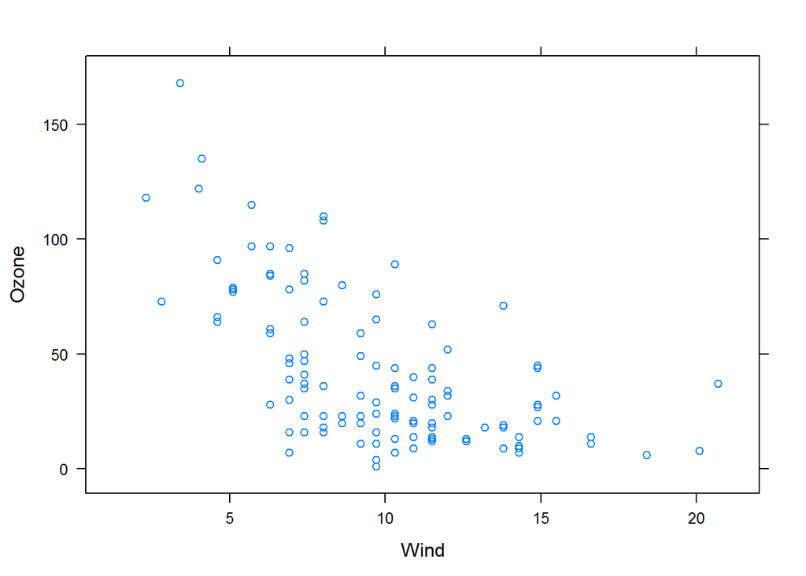

```r
library(lattice)
library(datasets)
## Simple scatter plot
xyplot(Ozone ~ Wind, data = airquality)
```

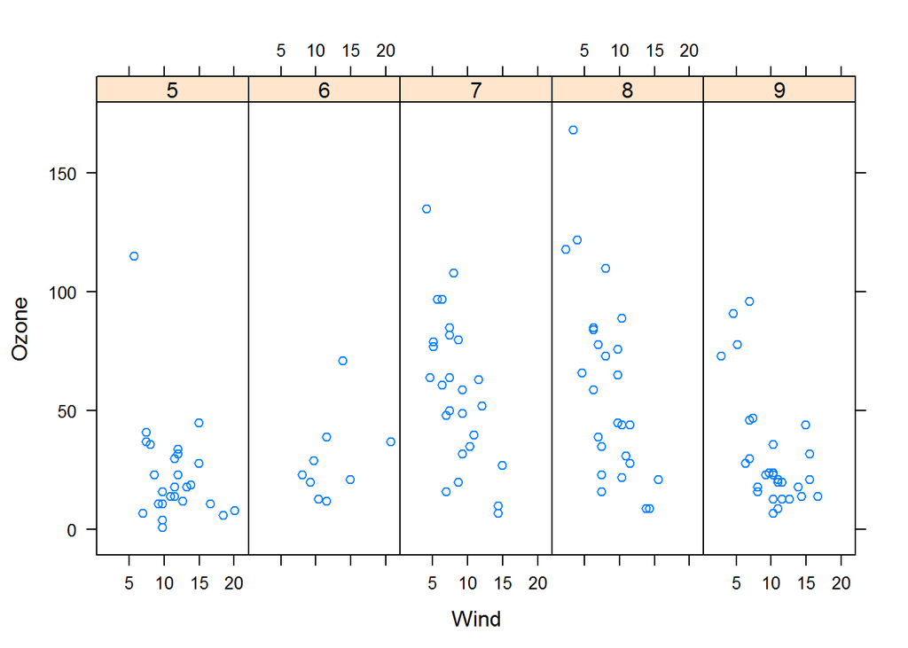

```r
## Convert 'Month' to a factor variable
airquality <- transform(airquality, Month = factor(Month))
xyplot(Ozone ~ Wind | Month, data = airquality, layout = c(5,1))
```

5. **Lattice Panel Functions**

> Panel functions can be specified/customized to modify what is plotted in each of the plot panels.

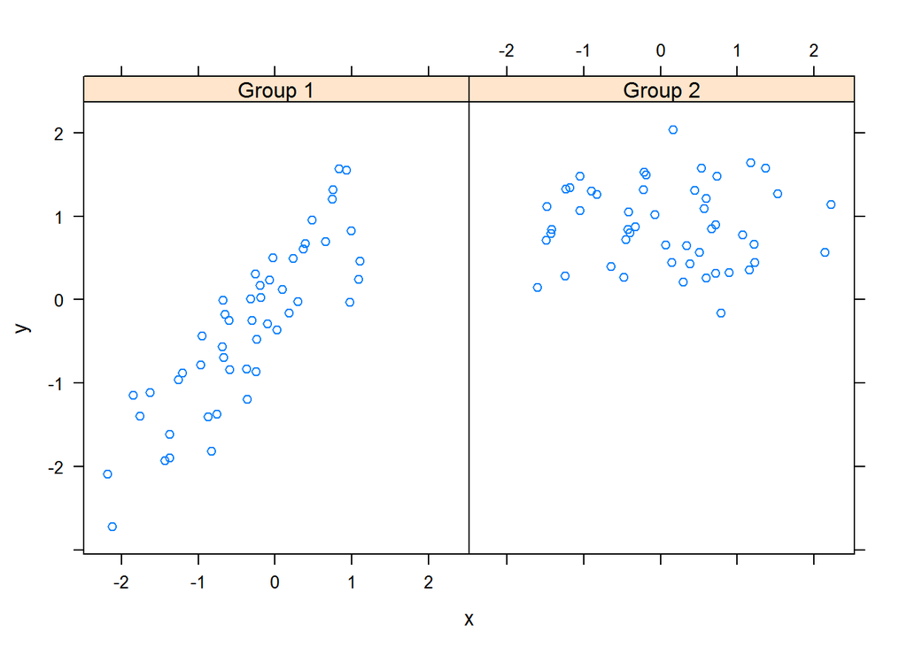

```r
set.seed(10)
x <- rnorm(100)
f <- rep(0:1, each = 50)
y <- x + f - f * x + rnorm(100,sd=0.5)
f <- factor(f,labels=c("Group 1","Group 2"))
xyplot(y~x | f, layout = c(2,1))
```

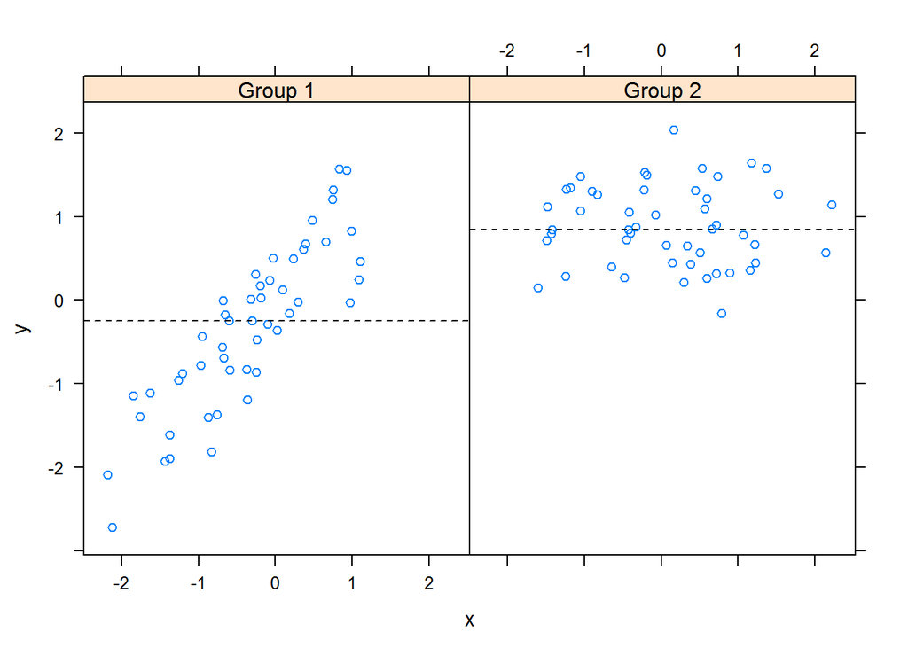

```r
## Custom panel function (abline)
xyplot(y ~ x | f, panel = function(x,y, ...) {
    panel.xyplot(x,y,...) # First call the default panel function for 'xyplot'
    panel.abline(h = median(y), lty = 2) # Add a horizontal line at the median
})
```

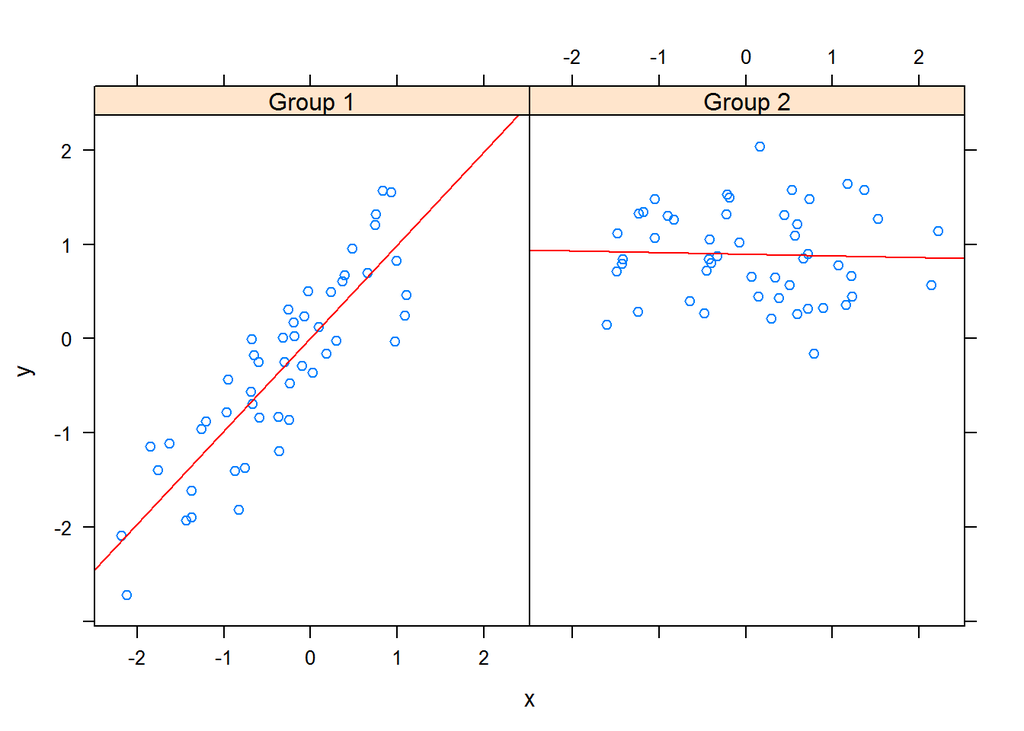

```r
## Regression line
xyplot(y ~ x | f, panel = function(x,y, ...) {
    panel.xyplot(x,y,...) # First call the default panel function for 'xyplot'
    panel.lmline(x,y,col=2) #Overlay a simple linear regression line
})
```

### The ggplot2 Plotting System

> The package ggplot2 is an implementation of the Grammar of Graphics.

#### Simple Plotting with qplot()

1. **Scatter graph**

```r
library(ggplot2)
qplot(displ,hwy,data=mpg)
qplot(displ,hwy,data=mpg,color=drv) #Auto legend placement when specified subsetting by drv;

# Adding a geom
qplot(displ,hwy,data=mpg,geom=c("point","smooth"))
```

2. **Histograms**

```r
qplot(hwy,data=mpg,fill=drv)
```

3. **Facets**

```r
qplot(displ,hwy,data=mpg,facets=.~drv)
qplot(hwy,data=mpg,facets=drv~.,binwidth=2)
# Facets = x ~ y where x means separate rows
# by variable x, y means separate columns by variable y.
```

#### Customizable ggplot2

1. **Basic Components of a ggplot2 Plot**
- A data frame
- Aesthetic mappings: how data are mapped to color, size
- Geoms: geometric objects like points, lines, sapes.
- Facets: for conditional plots
- Stats: statistical transformations like binning, quantiles, smoothing.
- Scales: what scale an aesthetic map uses (examples: male=red, female=blue).
- Coordinate system
2. **Building Plots with ggplot2**

Plots are built up in layers

- Plot the data
- Overlay a summary
- Metadata and annotation
3. **Basic Examples**

```
> g <- ggplot(mpg,aes(displ,hwy))
> print(g)
Error: No layers in plot
> p <- g+geom_point()
> p #Auto print (The same as print(p))
```

4. **Adding More Layers: Smooth**

`g + geom_point() + geom_smooth(method="lm")`

5. **Adding More Layers: Facets**

`g + geom_point() + facet_grid(.~drv)+geom_smooth(method="lm")`

6. **Annotation**
- Labels: xlab(), ylab(), labs(), ggtitle()
- For things that only make sense globally, use theme()
  - Example: theme(legend.position = “none”)
- Two standard appearance themes are included
  - Theme_gray(): The default theme (gray background)
  - Theme_bw(): More stark/plain
7. **Modifying aesthetics**

```r
g + geom_point(color = "steelblue", size=4, alpha=1/2)
g + geom_point(aes(color=drv),size=4,alpha=1/2)
# alpha specifies the transparency ?
```

8. **Modifying Labels**

```r
g + geom_point(aes(color=drv)) +
    labs(title="MAACS Cohort",
         x=expression("log "*PM[2.5]),
         y="Nocturnal Symptoms")
```

9. **A Note about Axis Limits**

```r
x <- 1:100
y <- rnorm(100)
testdat <- data.frame(x,y)
testdat[50,2] <- 100 ## Outlier!
plot(testdat$x,testdat$y,type="l",ylim = c(-3,3))
g <- ggplot(testdat, aes(x=x,y=y)) ## ggplot
g + geom_line()
# 1. Outlier missing
g + geom_line() + ylim(-3,3)
# 2. Outlier included
g + geom_line() + coord_cartesian(ylim=c(-3,3))
```

10. **Categorize on Continuous Variable**

    ```
    > ## Calculate the deciles of the data (Making NO2 (Nitrogen dioxide) tertiles)
    > cutpoints <- quantile(maacs$logno2_new, seq(0, 1, length=4), na.rm = TRUE)
    > ## Cut the data at the deciles and create a new factor variable
    > maacs$no2dec <- cut(maacs$logno2_new, cutpoints)
    > ## See the levels of the newly created factor variable
    > levels(maacs$no2dec)
    [1] "(0.378, 1.2]" "(1.2, 1.42]" "(1.42, 2.55]"
    ```

### Working with Color in R Plots

1. **Built-in Package: grDevices**

This package has two functions:

- colorRamp
- colorRampPalette
- The function `colors()` lists the names of colors you can use in any plotting function.
2. **colorRamp {grDevices}**

```r
pal <- colorRamp(c("red","blue"))
print(pal(0)) #[1 is Red] [2 is Green] [3 is Blue]
```

```
##      [,1] [,2] [,3]
## [1,]  255    0    0
```

```r
print(pal(1)) # pal(i), where 0 <= i <= 1
```

```
##      [,1] [,2] [,3]
## [1,]    0    0  255
```

3. **colorRampPalette {grDevices}**

```r
pal <- colorRampPalette(c("red","yellow"))
print(pal(2))
```

```
## [1] "#FF0000" "#FFFF00"
```

```r
# For example in the first element "FF0000":
# First pair (FF): Red
# Second pair (00): Green
# Third pair (00): Blue
print(pal(10))
```

```
##  [1] "#FF0000" "#FF1C00" "#FF3800" "#FF5500" "#FF7100" "#FF8D00" "#FFAA00"
##  [8] "#FFC600" "#FFE200" "#FFFF00"
```

> “#FF0000” : Red  
> “#FFFF00” : Yellow
4. **Package RColorBrewer**

There are 3 types of palettes

- Sequential
- Diverging
- Qualitative

The color information can be used conjunctively with the two functions in package grDevices.

5. **Use RColorBrewer and colorRampPalette Together**

```r
library(RColorBrewer)
cols <- brewer.pal(3,"BuGn") # I want 3 colors
# ?brewer.pal # To look up the names of the palettes.
print(cols)
```

```
## [1] "#E5F5F9" "#99D8C9" "#2CA25F"
```

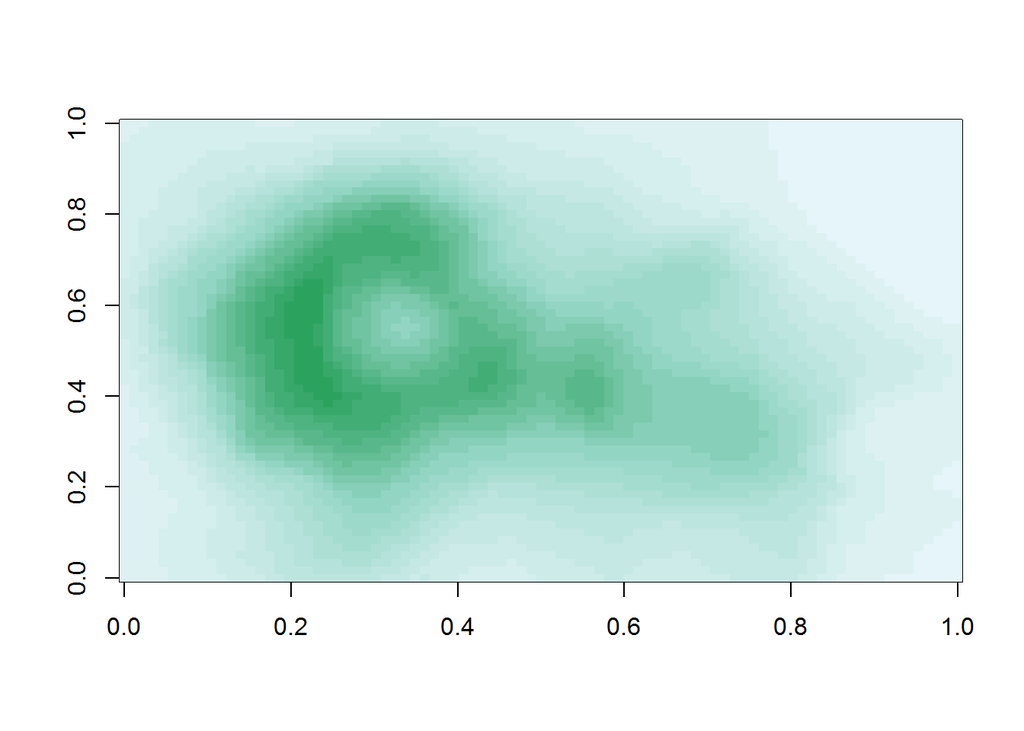

```r
pal <- colorRampPalette(cols)
image(volcano, col=pal(20))
```

6. **The smoothScatter Function**

```
## Copyright M. P. Wand 1997-2009
```

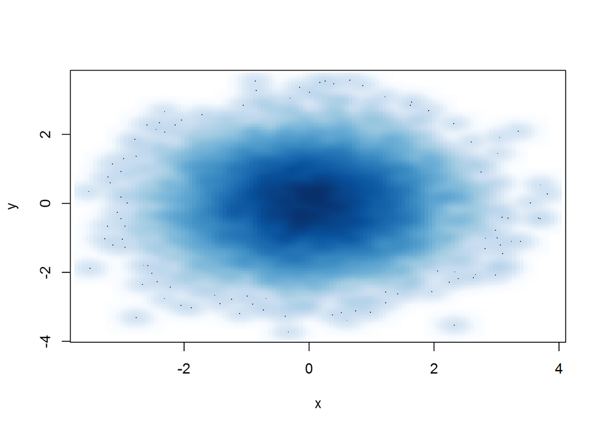

```r
# When you have many points to plot
x <- rnorm(10000)
y <- rnorm(10000)
smoothScatter(x,y)
```

7. **The rgb Function**

Please use `?rgb` to check the help page.

- The rgb function can be used to produce any color via red, green, blue proportions
- Color transparency can be added via the alpha parameter to rgb
8. **Scatterplot with Transparency**

```r
plot(x,y,pch=19)
# Versus:
plot(x,y,col = rgb(0,0,0,0.2),pch=19)
```